# Stplanr: Ulaşım Planlama (Transport Planning) Paketi

Buse Demir

09 01 2022

# MAKALE

The R Journal: article published in 2018, volume 10:2

stplanr: A Package for Transport Planning

Robin Lovelace and Richard Ellison

url->[https://journal.r-project.org/archive/2018/RJ-2018-053/RJ-2018-053.pdf]

# Paketin Kurulması ve İçeriği

```r
library(stplanr)
```

Stplanr paketi, R ile sürdürülebilir ulaşım planlaması için kullanılan bir pakettir.

A noktasından B noktasına en iyi ulaşım planlamasını ve modellemesini yapmak için kullanılır.

- Esnek ve çeşitli veri formatlarını işleyebilir.
- Ölçeklenebilir tek sokaklardan, büyük şehirlere ve bölgelere kadar birden çok coğrafi düzeyde çalışabilir.
- Bir dizi veri kümesi üzerinde test edilmiş ve çalışabilen gerçek dünya projelerinde kullanılabilir.

# AMAÇ

1. Ulaşım altyapısına ve davranışına ilişkin verilere erişme ve bunları işleme
2. Ulaşım ağının analizi ve görselleştirilmesi
3. Başlangıç-hedef verilerinin analizi ve ortaya çıkan görselleştirme (‘istenen çizgiler (desire lines)’)
4. Yönlendirme hizmetleri aracılığıyla yollara ve diğer kılavuzlara istek hatlarının atanması
5. Toplama aktarım ağı genelindeki segmentlerdeki toplam akış seviyelerini tahmin etmek için kullanılan rotalar
6. Ulaşım tahmini için modellerin geliştirilmesi
7. Ulaşım altyapısından etkilenen “yakalanma alanlarının” hesaplanması

# Ulaşım Verisi Türleri

1. Başlangıç-hedef rotaları arasında seyahat eden kişi sayısının rapor ediliği başlangıç-hedef (OD) verileri (OD veri setleri genellikle veri çerçeveleri (data frame) olarak gösterilir)
2. Hat verileri, dünya yüzeyinde tek boyutlu doğrusal unsurlar. Genellikle “SpatialLinesDataFrame” nesnesi olarak saklanır.
3. Rota verileri, taşıma ağına tahsis edilmiş özel hat türleridir. Rotalar genellikle bir Route_Function ile rota ağına atanan düz bir “istek hattının” tahsis edilmesiyle sonuçlanır. Tesisat ağı, çakışan birçok rotayı temsil eder. Tümü genellikle “SpatialLinesDataFrame” nesnesi olarak saklanır.
- OD, hat ve rota veri tipleri ile çalışmak veya oluşturmak için fonksiyon seçimleri aşağıda gösterilmiştir.

```
##   Function           Input data type(s)                 Output data type
## 1 od_dist            Data frame                        Numeric vector
## 2 od_id_order        Data frame                        Data frame
## 3 line_bearing       Spital line                       Numeric vector
## 4 line_midpoint      Spital line                       Spital points
## 5 route_cyclestreets Coordinates, spital point or text Spital lines
## 6 route_graphhooper  Coordinates, spital point or text Spital lines
```

### OD Verisi nedir?

Başlangıç-varış (OD) verileri, bir başlangıç noktasından (O) bir varış noktasına (D) kadar coğrafi alan boyunca hareketi temsil eder. Bazen “akış verileri” olarak da adlandırılan OD veri kümeleri, iki coğrafi nokta veya daha yaygın olarak bölgeler (genellikle bir bölge merkezi ile temsil edilir) arasındaki yolculukların ayrıntılarını içerir. Başlangıç ve varış noktaları arasındaki rotalara, coğrafi bilgilere *OSRM*, *Google Directions API*, *CycleStreets.net* or *OpenRouteServic*e gibi yönlendirme hizmetleri kullanılarak ulaşılabilir.

- Birçok ulaşım planlama modelinin önemli bir bileşeni olan OD verileri, *stplanr* paketindeki verilere ve işlevlere dayalı örneklerle tanıtılmaktadır. Amaç, örneğin otomobillerden yürüyüş, bisiklete binme ve toplu taşıma gibi daha düşük enerji modellerine geçişe neden olabileceği ‘istek çizgilerini’ belirleyerek daha sürdürülebilir ulaşım planlarını bilgilendirmek için OD verilerini kullanmanızı sağlamaktır.

# Rota Örneği

```r
library(osrm)
```

```r
rota1 <- route(from = c(-0.11, 51.514),to = c(-0.10, 51.506),route_fun = osrmRoute,returnclass = "sf")
mapview::mapview(rota1)
```

[interactive chart not shown]

- *stplanr* ve *osrm* paketleriyle Londra’daki Thames Nehri üzerinde Fleet Caddesi ile Southwark Caddesi arasındaki rota, route() fonksiyonu ile enlem/boylam girişleri kullanılarak hesaplanmıştır. Mapview fonksiyonu yardımı ile görselleştirilmiştir.

```r
rota2 <- route(from = "Leeds",to = "Bradford",route_fun = osrmRoute,returnclass = "sf")
mapview::mapview(rota2)
```

[interactive chart not shown]

## Coğrafi istek çizgilerinin (desire line) oluşturulması

Coğrafi bölgeler arasında seyahat eden insan sayısını temsil eden başlangıç-varış (OD) verileri, ulaşım planlaması için önemlidir. OD verileri genellikle (wicid.ukdataservice.ac.uk/ gibi) toplu veri kaynaklarından alınır ve bu nedenle tüm ülkenin seyahat modellerini uygun boyutlu dosyalarda temsil edebilir. Bir matris veya data frame olarak saklanabilirler. Aşağıda eğitim ve gösterim amacıyla stplanr ile sağlanan, Birleşik Krallık’taki yerleşim bölgeleri arasındaki evden işe gidip gelme sayısını temsil eden bir veri çerçevesi (data frame) olan *flow (akış) verisi* örneği gösterilmiştir.

- *All* sütunu bölgeler arası seyehat eden kişi sayısını gösterirken *Bicycle* gibi sütunlar(caravan, train,metro, on foot) hangi aracın kaç kişi tarafından kullanıldığını gösterir.

```r
data("flow", package = "stplanr")
head(flow[c(1:3, 12)])
```

```
##        Area.of.residence Area.of.workplace All Bicycle
## 920573         E02002361         E02002361 109       2
## 920575         E02002361         E02002363  38       0
## 920578         E02002361         E02002367  10       0
## 920582         E02002361         E02002371  44       3
## 920587         E02002361         E02002377  34       0
## 920591         E02002361         E02002382   7       0
```

- Yukarıda görüntülenen akış verileri coğrafi alan üzerindeki hareketi tanımlasa da, açıkça coğrafi bilgi içermez. Bunun yerine, başlangıç ve varış noktalarının koordinatları aşağıda gösterildiği gibi ayrı bir coğrafi veri kümesiyle (cents veri kümesiyle temsil edilir) bağlantılıdır.

```r
data("cents", package = "stplanr")
as.data.frame(cents[1:3, -c(3,4)])
```

```
##       geo_code  MSOA11NM coords.x1 coords.x2
## 1708 E02002384 Leeds 055 -1.546463  53.80952
## 1712 E02002382 Leeds 053 -1.511861  53.81161
## 1805 E02002393 Leeds 064 -1.524205  53.80410
```

- İki veri kümesini birbirine bağlamak için *od2line* fonksiyonu kullanılır.

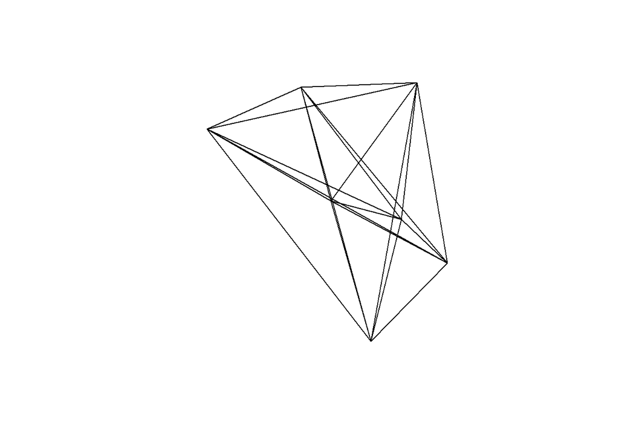

```r
l <- od2line(flow = flow, zones = cents)
plot(l)
```

## Bisiklet Verisi Modellemesi

*Stplanr* paketi kullanılarak Open Street Maps’ten (OSM) alınan veriler *bikedata* paketi ile bisiklet paylaşımı verilerini de kullanabilir. bikedata paketi kullanılarak erişilebilen bisiklet paylaşım verileri, bisiklet paylaşım sistemlerinden başlangıç-varış (OD) akışları ürettiği için stplanr ile entegrasyon için uygundur. Bu veriler, olası yolları oluşturmak için *sum_network_links* fonksiyonu ile birlikte kullanılırlar. (Makalede veri seti ile ilgili bir bilgi verilmemiştir. Sadece görsel kullanılmıştır. bikedata paketi R’ın bu versiyonu için bulunamamıştır hatası alınmıştır. Detaylar için aşağıdaki linke tıklayabilirsiniz. [https://docs.ropensci.org/bikedata/articles/bikedata.html] )

[figure not shown]

“Newyork’taki ortak bisiklet rotalarının modellenmesi”

- Modelde turuncu çizgiler insanlar tarafından en çok kullanılan rotaları gösterirken (8.0000-100.000(+)) açık renkli rota çizgileri ise insanlar tarafından daha az tercih edilen rotları göstermektededir.

# Rota Modellemesi

[https://CycleStreets.net] adresinden API anahtarı talebinde bulunabilirsiniz.

(Benim aldığım API şifresi: 114cd5e2a142f24a)

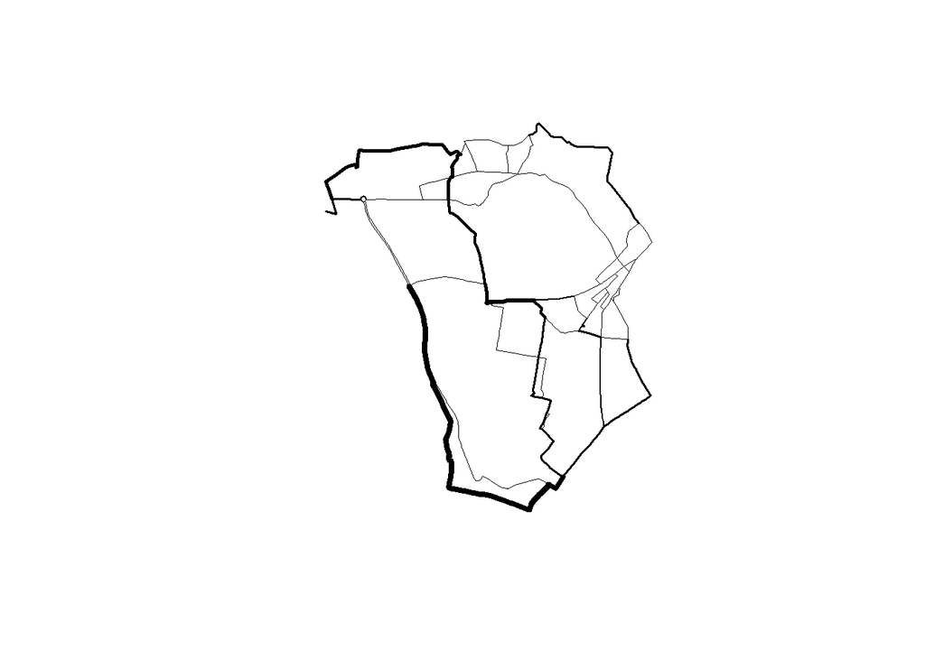

```r
routes_fast$All <- l$All
rnet <- overline(routes_fast, "All", fun = sum)
rnet$flow <- rnet$All / mean(rnet$All) * 3
plot(rnet, lwd = rnet$flow / mean(rnet$flow))
```

# Seyahat Toplama Alanlarının Modellenmesi

- Toplanma alanları, ulaşım planlamasında kullanılın önemli analitik ve görsel araçlardandır. Örneğin yeni bir otobüs durağından kimin yararlanacağına yardımcı olabilir ve coğrafi durumu örnekleyebilirler. Yolcuların genelde otobüs duraklarına 400 tren istasyonlarına ise 800 metreye kadar yürümeye istekli oldukları söylenmektedir. Stplanr paketi *calc_catchment* fonksiyonu ile düz çizgi (straight line) mesafelerini kullanarak toplanma alanlarını hesaplar.
- *calc_catchment* ve *calc_network_catchment* fonksiyonları, toplama alanlarının hesaplanmasına izin veren tamamlayıcı fonksiyonlardır.
- Aşağıda *calc_catcment* fonksiyonu ile Sidney’deki sokaklara hizalanmış bisiklet yollarını içeren *testcycleway* veri seti görselleştirilmiştir.

```r
data_dir <- system.file("extdata", package = "stplanr")
unzip(file.path(data_dir, 'smallsa1.zip'))
unzip(file.path(data_dir, 'testcycleway.zip'))
sa1income <- rgdal::readOGR(".", "smallsa1")
testcycleway <- rgdal::readOGR(".", "testcycleway")
file.remove(list.files(pattern = "^(smallsa1|testcycleway).*"))
```

```
## [1] TRUE TRUE TRUE TRUE TRUE TRUE TRUE TRUE TRUE
```

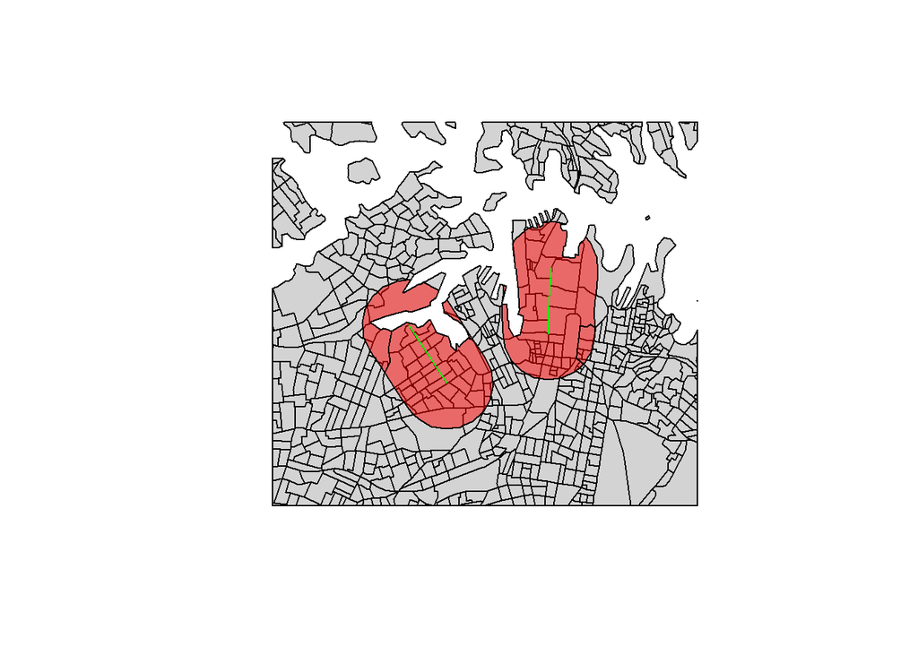

```r
catch800m <- calc_catchment( polygonlayer = sa1income,targetlayer = testcycleway,calccols = c('Total'),
  distance = 800,projection = 'austalbers',dissolve = TRUE)
plot(sa1income, col = "light grey")
plot(catch800m, col = rgb(1, 0, 0, 0.5), add = TRUE)
plot(testcycleway, col = "green", add = TRUE)
```

- Yukarıdaki görselde Sidney’de düz çizgi mesafesini kullanan bir bisiklet yolu (yeşil) ile ilişkili 800 metrelik bir toplama alanı (kırmızı) gösterilmiştir.

# Modelleme ve Görselleştirme

- Şu anda mesafe azalmasını modellemek için kullanılabilir hiçbir fonksiyon bulunmamaktadır.(Ancak bu *stplanr* paketinin gelecekteki sürümlerine eklemek istenilen bir şeydir.)
- Stplanr tarafından oluşturulan aynı nesneyi (l) kullanarak yürüyerek yapılan yolculukların oranı ile mesafe arasındaki ilişkiyi keşfedebiliriz.

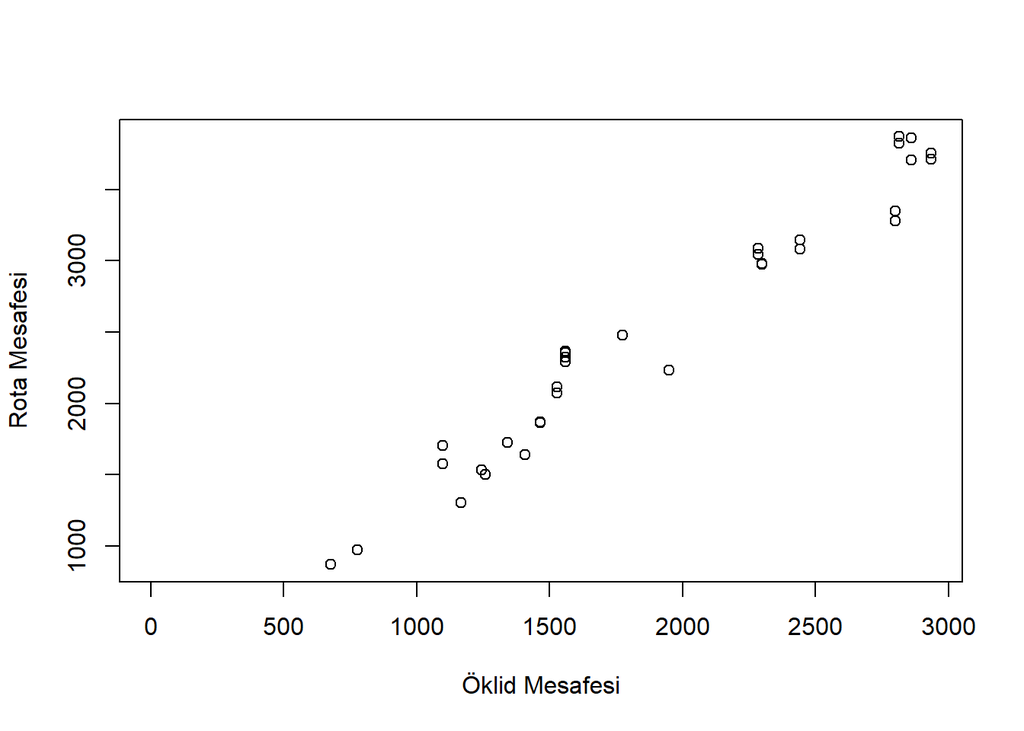

```r
l$d_euclidean <- line_length(l)
l$d_rf <- routes_fast@data$length
plot(l$d_euclidean, l$d_rf,xlab = "Öklid Mesafesi", ylab = "Rota Mesafesi")
```

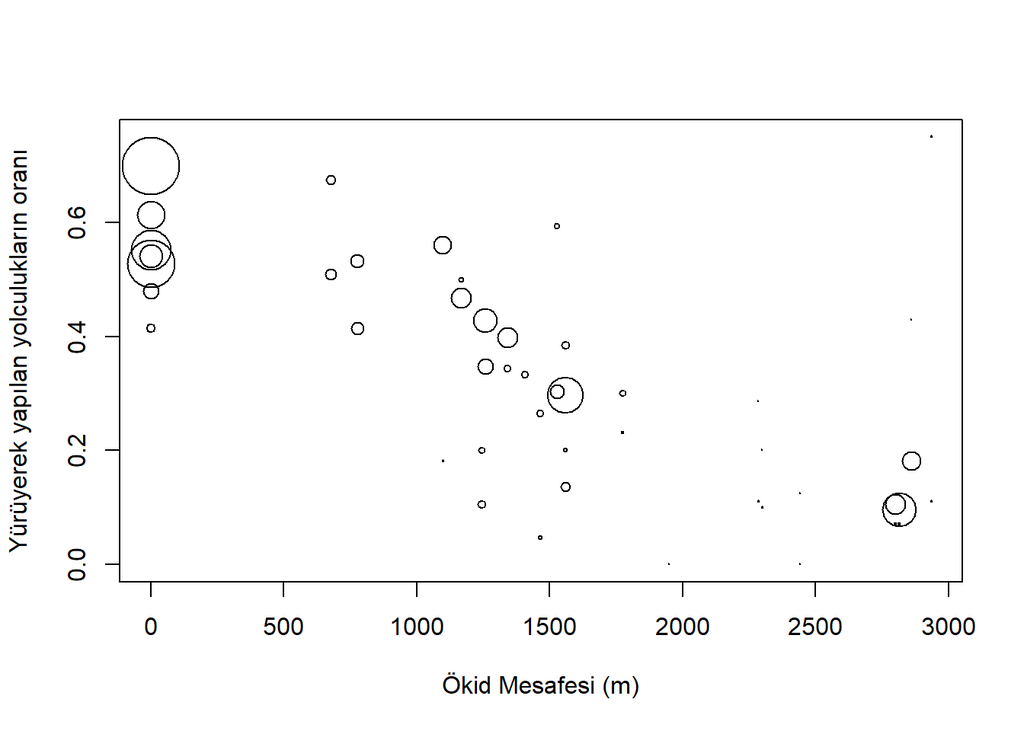

```r
l$pwalk <- l$On.foot / l$All
plot(l$d_euclidean, l$pwalk, cex = l$All / 50,
xlab = "Ökid Mesafesi (m)", ylab = "Yürüyerek yapılan yolculukların oranı")
```

- Öklid mesafesi ve en hızlı rota mesafesi (ilk görsel); Öklid mesafesi ile yürüyerek yapılan gezilerin oranı (ikinci görsel) gösterilmiştir. İkinci görsele bakıldığında yolculukların mesafesi ile yürüyerek yapılan yolculukların oranı arasında negatif bir ilişki olduğu gözlemlenmiştir.
- Belirli bir mesafenin ötesinde (yukarıdaki şekilde sunulan verilere göre yaklaşık 1,5 km) yürüme genellikle yavaş bir araç olduğu için diğer modeller(araçlar) dikkate alınır. Burdaki “mesafe azalması” doğrusal değildir ve bir dizi fonksiyonla yaklaşık olarak tahmin edilebilir.

### Görselleştirme

- Görselleştirme, araştırmacıların bulgularını diğer araştırmacılara ve halka iletmesine olanak tanıdığından, herhangi bir ulaşım çalışmasının önemli bir yönüdür. Bu nedenle, stplanr’ın görselleştirme için hiçbir fonksiyon içermemesi şaşırtıcıdır. Bunun yerine, kullanıcılar *mapview*, *tmap*, *leaflet* ve *ggmap* gibi R’deki mevcut görselleştirme araçlarını kullanmaya teşvik edilir.

## Makaleye genel bakış ve paketin geliştirilmesi

Bu makalede, ulaşım planlamasının R programı ile yapılabileceğini gösterilmektedir. Stplanr paketi bilindiği kadarıyla uygulayıcıların ve araştırmacıların daha sürdürülebilir ulaşım sistemleri tasarlamasını sağlamayı amaçlayan ilk R paketidir ve aynı şeyi yapan mevcut paketlerin olmaması, dikkatleri daha gelişmiş özelliklerden ziyade stplanr’ın temel işlevselliğine yönlendirmektedir. Örnek olarak yakın zamanda eklenen route_local fonksiyonu da dahil olmak üzere gelecekteki gelişmeler için bir destek sağlayabilecek SpatialLinesNetwork sınıfı verilebilir.

- *stplanr* paketi ayrıca, uzay ve MCI gibi uzamsal taşıma verilerini kullanan diğer R paketleriyle birlikte de kullanılabilir.
- Aslında ilk olarak İngiltere’deki ve Galler’deki tüm büyük bisiklet rotalarındaki bisiklet potansiyelini tahmin eden Döngüye Yönelik Eğilim Aracı (PCT) için veri oluşturmak üzere geliştirilmiştir. Ulaşım veri kümelerini analiz etmek için açık erişim veri paketlerinin kullanılabilirliğinin artmasıyla bu paketin, başka birçok ulusal ve uluslararası ulaşım planlaması sorununu çözmek için kullanılabileceğine inanılmaktadır.

# KAYNAKÇA

-> G. Boeing. OSMnx: New methods for acquiring, constructing, analyzing, and visualizing complex street networks. Computers, Environment and Urban Systems, 65:126–139, 2017. URL [https://doi. org/10.1016/j.compenvurbsys.2017.05.004.]

-> [https://towardsdatascience.com/automating-running-routes-in-r-1e97eb4ed716]

-> D. E. Boyce and H. C. W. L. Williams. Forecasting Urban Travel: Past, Present and Future. Edward Elgar Publishing, 2015. [p7]

-> P. E. Brown. Maps, Coordinate Reference Systems and Visualising Geographic Data with mapmisc. The R ournal, 8(1):64–91, 2016. URL [https://journal.r-project.org/archive/2016/RJ-2016- 005/index.html.]

-> P. E. Brown and L. Zhou. diseasemapping: Modelling Spatial Variation in Disease Risk for Areal Data, 2016. URL [https://CRAN.R-project.org/package=diseasemapping]

-> L. M. Martínez and . M. Viegas. A new approach to modelling distance-decay functions for accessibility assessment in transport studies. Journal of Transport Geography, 26:87–96, 2013. URL[https://doi. org/10.1016/j.jtrangeo.2012.08.018.]

-> [https://www.cyclestreets.net/]

-> [https://rdrr.io/cran/stplanr/man/route_local.html]

-> Lovelace, M. Birkin, P. Cross, and M. Clarke. From Big Noise to Big Data: Toward the Verification of Large Data sets for Understanding Regional Retail Flows. Geographical Analysis, 48(1):59–81, 2016. URL [https://doi.org/10.1111/gean.12081.]

-> M. Diana. Studying Patterns of Use of Transport Modes Through Data Mining. Transportation Research Record: Journal of the Transportation Research Board, 2308:1–9, 2012. URL [https://doi.org/10.3141/ 2308-01]